# pfcsp mosquito abdomen sharing model prep descriptives

Kelsey Sumner

10/24/2019

# Set up work environment

## Load packages

```r
library(readr)
library(lme4)
```

```r
library(moments)
library(ggplot2)
library(epiDisplay)
library(dplyr)
```

## Read in the csp abdomen data set

This data set shows the pairs of human asymptomatic and symptomatic infections with mosquito abdomens that were Pf positive and collected within the same household as the human, 0-14 days after the human infection was reported.

```r
csp_abdomens <- read_rds("~/Desktop/clean_ids_haplotype_results/CSP/spat21_csp_edgelist_abdomen_29OCT2019.rds")
```

# Check data set up prior to running models

## Make sure variables all coded correctly prior to running models

Check that the exposure, outcome, and covariates are coded correctly

```r
# make sure the exposure and outcome are coded correctly
str(csp_abdomens$aim2_exposure)
```

```
##  chr [1:350] "symptomatic infection" "asymptomatic infection" ...
```

```r
csp_abdomens$aim2_exposure = as.factor(csp_abdomens$aim2_exposure)
str(csp_abdomens$haps_shared)
```

```
##  int [1:350] 0 0 1 2 2 2 1 0 3 3 ...
```

```r
str(csp_abdomens$village_name)
```

```
##  chr [1:350] "Maruti" "Kinesamo" "Maruti" "Maruti" "Kinesamo" "Maruti" ...
```

```r
csp_abdomens$village_name = as.factor(csp_abdomens$village_name)
str(csp_abdomens$pfr364Q_std_combined)
```

```
##  num [1:350] 1420.832 733.604 19.37 0.261 375.373 ...
```

```r
str(csp_abdomens$age_cat_baseline)
```

```
##  chr [1:350] "5-15 years" "5-15 years" ">15 years" "<5 years" ...
```

```r
csp_abdomens$age_cat_baseline = as.factor(csp_abdomens$age_cat_baseline)
str(csp_abdomens$sample_id_human)
```

```
##  chr [1:350] "M14-210617-5-R" "K14-060717-4" "M07-130617-1" ...
```

```r
str(csp_abdomens$unq_memID)
```

```
##  chr [1:350] "M14_5" "K14_4" "M07_1" "M07_2" "K14_4" "M15_1" "M15_2" ...
```

```r
str(csp_abdomens$HH_ID)
```

```
##  chr [1:350] "M14" "K14" "M07" "M07" "K14" "M15" "M15" "M15" "M15" ...
```

```r
str(csp_abdomens$age_all_baseline)
```

```
##  chr [1:350] "11" "12" "78" "3" "12" "58" "19" "2" "7" "22" "24" "5" ...
```

```r
csp_abdomens$age_all_baseline = as.numeric(csp_abdomens$age_all_baseline)
```

Look at a summary of the variables in the analysis set.

```r
# look at a summary of aim2_exposure
table(csp_abdomens$aim2_exposure, useNA = "always")
```

```
##
## asymptomatic infection  symptomatic infection                   <NA>
##                    268                     82                      0
```

```r
# look at haps_shared
summary(csp_abdomens$haps_shared)
```

```
##    Min. 1st Qu.  Median    Mean 3rd Qu.    Max.
##   0.000   0.000   1.000   1.394   2.000   8.000
```

```r
sd(csp_abdomens$haps_shared)
```

```
## [1] 1.490744
```

```r
skewness(csp_abdomens$haps_shared)
```

```
## [1] 1.385072
```

```r
kurtosis(csp_abdomens$haps_shared)
```

```
## [1] 5.194706
```

```r
# look at pfr364Q_combined_std
summary(csp_abdomens$pfr364Q_std_combined)
```

```
##     Min.  1st Qu.   Median     Mean  3rd Qu.     Max.
##     0.21     9.88   230.93  3538.29  3229.46 56148.99
```

```r
sd(csp_abdomens$pfr364Q_std_combined)
```

```
## [1] 10371.68
```

```r
skewness(csp_abdomens$pfr364Q_std_combined)
```

```
## [1] 4.498007
```

```r
kurtosis(csp_abdomens$pfr364Q_std_combined)
```

```
## [1] 22.57795
```

```r
# look at age_cat
table(csp_abdomens$age_cat_baseline, useNA = "always")
```

```
##
##   <5 years  >15 years 5-15 years       <NA>
##         49        111        190          0
```

```r
table(csp_abdomens$age_all_baseline, useNA = "always")
```

```
##
##    1    2    3    4    5    6    7    8    9   10   11   12   13   14   15
##    4   16   26    3   19   12   19   23    2   49   15   25    1    3   22
##   16   17   19   22   24   25   26   28   33   36   43   52   58   64   68
##    3   22   12    8    3    1    9    1   10   18    1    1    8    2    5
##   70   78 <NA>
##    1    6    0
```

```r
summary(csp_abdomens$age_all_baseline)
```

```
##    Min. 1st Qu.  Median    Mean 3rd Qu.    Max.
##    1.00    7.00   11.00   16.27   17.00   78.00
```

```r
table(csp_abdomens$age_cat_baseline,csp_abdomens$age_all_baseline,useNA = "always")
```

```
##
##               1  2  3  4  5  6  7  8  9 10 11 12 13 14 15 16 17 19 22 24
##   <5 years    4 16 26  3  0  0  0  0  0  0  0  0  0  0  0  0  0  0  0  0
##   >15 years   0  0  0  0  0  0  0  0  0  0  0  0  0  0  0  3 22 12  8  3
##   5-15 years  0  0  0  0 19 12 19 23  2 49 15 25  1  3 22  0  0  0  0  0
##   <NA>        0  0  0  0  0  0  0  0  0  0  0  0  0  0  0  0  0  0  0  0
##
##              25 26 28 33 36 43 52 58 64 68 70 78 <NA>
##   <5 years    0  0  0  0  0  0  0  0  0  0  0  0    0
##   >15 years   1  9  1 10 18  1  1  8  2  5  1  6    0
##   5-15 years  0  0  0  0  0  0  0  0  0  0  0  0    0
##   <NA>        0  0  0  0  0  0  0  0  0  0  0  0    0
```

```r
# look at village_name
table(csp_abdomens$village_name, useNA = "always")
```

```
##
##  Kinesamo    Maruti Sitabicha      <NA>
##       163       175        12         0
```

```r
# look at sample_id_human
table(csp_abdomens$sample_id_human, useNA = "always")
```

```
##
## K01-030817-2-R   K01-030817-3   K01-030817-4   K01-030817-6   K01-030817-7
##              7              7              7              7              7
##   K01-030817-8   K01-060717-2   K01-060717-3   K01-060717-4   K01-060717-5
##              7             11             11             11             11
##   K01-060717-6   K01-060717-7   K01-060717-8 K01-080717-3-R   K01-120617-5
##             11             11             11             11              2
##   K01-120617-6   K01-120617-7   K01-120617-8 K01-200617-5-R K01-200617-6-R
##              2              2              2              3              3
##   K02-070917-4   K02-070917-5   K02-070917-7   K05-030817-2 K05-300617-3-R
##              1              1              1              1              2
##   K07-130717-8   K11-051017-2   K14-010218-4   K14-030817-4   K14-040518-1
##              1              1              1              5              1
##   K14-040518-3   K14-040518-4   K14-060418-4   K14-060717-4 M01-050917-3-R
##              1              1              1              1              1
## M01-110717-5-R   M01-130717-3   M01-130717-4   M01-130717-5   M01-130717-7
##              2              1              1              1              1
##   M01-140917-1   M01-140917-3   M01-140917-6   M04-170817-1 M04-260717-3-R
##              1              1              1              3              2
## M04-280617-3-R   M05-100518-4   M05-100518-6   M05-140618-1   M05-140618-4
##              1              1              1              1              1
##   M05-140618-6 M05-260618-4-R   M06-121017-1   M06-121017-2   M06-121017-4
##              1              1              1              1              1
##   M06-130617-1   M06-130617-2   M06-130617-3 M06-130617-4-R   M06-130717-1
##              1              1              1              1              4
##   M06-130717-2   M06-130717-3   M06-130717-4   M06-170817-1   M06-170817-2
##              4              4              4              3              3
##   M06-170817-3   M06-170817-4 M06-240817-3-R   M07-100518-3   M07-121017-3
##              3              3              3              1              1
##   M07-130617-1   M07-130617-2   M07-170817-3   M09-130617-2   M09-130617-3
##              6              6              3              7              7
##   M09-130717-2   M09-130717-4   M09-140917-1   M09-140917-3   M09-140917-4
##              3              3              1              1              1
##   M09-170817-1   M09-170817-2   M09-170817-3   M09-170817-4   M12-170817-1
##              1              1              1              1              1
##   M13-130717-2   M13-130717-4   M13-130717-7   M13-130717-8   M13-130717-9
##              1              1              1              1              1
## M14-040618-4-R   M14-130617-2   M14-130617-5   M14-130617-6 M14-210617-5-R
##              1              2              2              2              5
##   M15-130617-1   M15-130617-2   M15-130617-3   M15-130617-4   M15-130617-5
##              2              2              2              2              2
##   M15-130717-1   M15-130717-2   M15-130717-3   M15-130717-4   M15-130717-5
##              4              4              4              4              4
##   M15-140917-2   M15-140917-3   M15-140917-4   M15-140917-5   M15-170817-1
##              1              1              1              1              2
##   M15-170817-2   M15-170817-5 M16-030518-4-R M16-030518-5-R M16-070518-6-R
##              2              2              1              1              1
##   M16-120418-2   M16-120418-3   M16-120418-5 M16-280318-5-R S02-120717-3-R
##              3              3              3              1              2
## S02-120717-5-R   S04-170518-8   S04-200717-7   S04-200717-8   S08-140617-3
##              2              1              1              1              1
##   S08-140617-4   S08-140617-7   S11-140617-5   S11-140617-8           <NA>
##              1              1              1              1              0
```

```r
table(csp_abdomens$sample_id_abdomen, useNA = "always")
```

```
##
## K01 A00006 K01 A00007 K01 A00010 K01 A00011 K01 A00013 K01 A00016
##          4          4          2          2          2          8
## K01 A00017 K01 A00018 K01 A00019 K01 A00021 K01 A00022 K01 A00023
##          8          8          8          8          8          8
## K01 A00024 K01 A00025 K01 A00028 K01 A00030 K01 A00035 K01 A00036
##          8          8          8          8          6          6
## K01 A00038 K01 A00039 K01 A00040 K01 A00041 K01 A00043 K02 A00024
##          6          6          6          6          6          3
## K05 A00005 K05 A00006 K05 A00015 K07 A00010 K11 A00008 K14 A00005
##          1          1          1          1          1          1
## K14 A00016 K14 A00019 K14 A00020 K14 A00021 K14 A00022 K14 A00037
##          1          1          1          1          1          1
## K14 A00044 K14 A00046 M01 A00012 M01 A00014 M01 A00031 M01 A00034
##          1          3          1          5          1          3
## M04 A00002 M04 A00010 M04 A00014 M04 A00019 M04 A00020 M04 A00022
##          1          1          1          1          1          1
## M05 A00037 M05 A00039 M06 A00008 M06 A00019 M06 A00021 M06 A00023
##          2          4          4          4          4          4
## M06 A00024 M06 A00039 M06 A00040 M06 A00041 M06 A00045 M07 A00001
##          4          5          5          5          3          2
## M07 A00007 M07 A00008 M07 A00010 M07 A00011 M07 A00017 M07 A00120
##          2          2          2          2          2          1
## M07 A00125 M07 A00126 M07 A00140 M07 A00176 M09 A00002 M09 A00006
##          1          1          1          1          2          2
## M09 A00008 M09 A00011 M09 A00012 M09 A00017 M09 A00018 M09 A00044
##          2          2          2          2          2          2
## M09 A00045 M09 A00046 M09 A00065 M09 A00079 M12 A00010 M13 A00017
##          2          2          4          3          1          5
## M14 A00003 M14 A00006 M14 A00008 M14 A00009 M14 A00018 M14 A00070
##          4          4          1          1          1          1
## M15 A00002 M15 A00005 M15 A00018 M15 A00026 M15 A00028 M15 A00030
##          5          5          5          5          5          5
## M15 A00050 M15 A00052 M15 A00058 M16 A00022 M16 A00024 M16 A00028
##          3          3          4          1          3          3
## M16 A00029 M16 A00032 S02 A00009 S02 A00010 S04 A00012 S04 A00033
##          3          3          2          2          2          1
## S08 A00002 S11 A00002       <NA>
##          3          2          0
```

```r
# look at unq_memID
table(csp_abdomens$unq_memID, useNA = "always")
```

```
##
## K01_2 K01_3 K01_4 K01_5 K01_6 K01_7 K01_8 K02_4 K02_5 K02_7 K05_2 K05_3
##    18    29    18    16    23    20    20     1     1     1     1     2
## K07_8 K11_2 K14_1 K14_3 K14_4 M01_1 M01_3 M01_4 M01_5 M01_6 M01_7 M04_1
##     1     1     1     1     9     1     3     1     3     1     1     3
## M04_3 M05_1 M05_4 M05_6 M06_1 M06_2 M06_3 M06_4 M07_1 M07_2 M07_3 M09_1
##     3     1     3     2     9     9    11     9     6     6     5     2
## M09_2 M09_3 M09_4 M12_1 M13_2 M13_4 M13_7 M13_8 M13_9 M14_2 M14_4 M14_5
##    11     9     5     1     1     1     1     1     1     2     1     7
## M14_6 M15_1 M15_2 M15_3 M15_4 M15_5 M16_2 M16_3 M16_4 M16_5 M16_6 S02_3
##     2     8     9     7     7     9     3     3     1     5     1     2
## S02_5 S04_7 S04_8 S08_3 S08_4 S08_7 S11_5 S11_8  <NA>
##     2     1     2     1     1     1     1     1     0
```

```r
# look at HH_ID
table(csp_abdomens$HH_ID, useNA = "always")
```

```
##
##  K01  K02  K05  K07  K11  K14  M01  M04  M05  M06  M07  M09  M12  M13  M14
##  144    3    3    1    1   11   10    6    6   38   17   27    1    5   12
##  M15  M16  S02  S04  S08  S11 <NA>
##   40   13    4    3    3    2    0
```

```r
# note: looks like a lot of multiple pairings where have a mosquito with many people and many people with a mosquito, especially in K01
# might want to do weighting to account for this
```

# Remove Sitabicha from analysis

Sitabicha was only included in 12 pairs (3%) of the final data set, so removing from the analysis because the small numbers are not representative of Sitabicha as a whole and will cause sparse data and model convergence issues.

```r
csp_abdomens = csp_abdomens %>%
  filter(!(village_name=="Sitabicha"))
```

Look at a summary of the variables in the analysis set with Sitabicha removed.

```r
# look at a summary of aim2_exposure
table(csp_abdomens$aim2_exposure, useNA = "always")
```

```
##
## asymptomatic infection  symptomatic infection                   <NA>
##                    263                     75                      0
```

```r
# look at haps_shared
summary(csp_abdomens$haps_shared)
```

```
##    Min. 1st Qu.  Median    Mean 3rd Qu.    Max.
##    0.00    0.00    1.00    1.42    2.00    8.00
```

```r
sd(csp_abdomens$haps_shared)
```

```
## [1] 1.502069
```

```r
skewness(csp_abdomens$haps_shared)
```

```
## [1] 1.361486
```

```r
kurtosis(csp_abdomens$haps_shared)
```

```
## [1] 5.106998
```

```r
# look at pfr364Q_combined_std
summary(csp_abdomens$pfr364Q_std_combined)
```

```
##     Min.  1st Qu.   Median     Mean  3rd Qu.     Max.
##     0.21     7.51   230.93  3502.58  2855.79 56148.99
```

```r
sd(csp_abdomens$pfr364Q_std_combined)
```

```
## [1] 10464.31
```

```r
skewness(csp_abdomens$pfr364Q_std_combined)
```

```
## [1] 4.516781
```

```r
kurtosis(csp_abdomens$pfr364Q_std_combined)
```

```
## [1] 22.56628
```

```r
# look at age_cat
table(csp_abdomens$age_cat_baseline, useNA = "always")
```

```
##
##   <5 years  >15 years 5-15 years       <NA>
##         46        109        183          0
```

```r
table(csp_abdomens$age_all_baseline, useNA = "always")
```

```
##
##    1    2    3    4    5    6    7    8    9   10   11   12   13   14   15
##    3   16   26    1   19   10   17   23    2   47   14   25    1    3   22
##   16   17   19   22   24   25   26   28   33   36   43   52   58   64   68
##    3   21   12    7    3    1    9    1   10   18    1    1    8    2    5
##   70   78 <NA>
##    1    6    0
```

```r
summary(csp_abdomens$age_all_baseline)
```

```
##    Min. 1st Qu.  Median    Mean 3rd Qu.    Max.
##    1.00    7.00   11.00   16.54   18.50   78.00
```

```r
table(csp_abdomens$age_cat_baseline,csp_abdomens$age_all_baseline,useNA = "always")
```

```
##
##               1  2  3  4  5  6  7  8  9 10 11 12 13 14 15 16 17 19 22 24
##   <5 years    3 16 26  1  0  0  0  0  0  0  0  0  0  0  0  0  0  0  0  0
##   >15 years   0  0  0  0  0  0  0  0  0  0  0  0  0  0  0  3 21 12  7  3
##   5-15 years  0  0  0  0 19 10 17 23  2 47 14 25  1  3 22  0  0  0  0  0
##   <NA>        0  0  0  0  0  0  0  0  0  0  0  0  0  0  0  0  0  0  0  0
##
##              25 26 28 33 36 43 52 58 64 68 70 78 <NA>
##   <5 years    0  0  0  0  0  0  0  0  0  0  0  0    0
##   >15 years   1  9  1 10 18  1  1  8  2  5  1  6    0
##   5-15 years  0  0  0  0  0  0  0  0  0  0  0  0    0
##   <NA>        0  0  0  0  0  0  0  0  0  0  0  0    0
```

```r
# look at village_name
table(csp_abdomens$village_name, useNA = "always")
```

```
##
##  Kinesamo    Maruti Sitabicha      <NA>
##       163       175         0         0
```

```r
# look at sample_id_human
table(csp_abdomens$sample_id_human, useNA = "always")
```

```
##
## K01-030817-2-R   K01-030817-3   K01-030817-4   K01-030817-6   K01-030817-7
##              7              7              7              7              7
##   K01-030817-8   K01-060717-2   K01-060717-3   K01-060717-4   K01-060717-5
##              7             11             11             11             11
##   K01-060717-6   K01-060717-7   K01-060717-8 K01-080717-3-R   K01-120617-5
##             11             11             11             11              2
##   K01-120617-6   K01-120617-7   K01-120617-8 K01-200617-5-R K01-200617-6-R
##              2              2              2              3              3
##   K02-070917-4   K02-070917-5   K02-070917-7   K05-030817-2 K05-300617-3-R
##              1              1              1              1              2
##   K07-130717-8   K11-051017-2   K14-010218-4   K14-030817-4   K14-040518-1
##              1              1              1              5              1
##   K14-040518-3   K14-040518-4   K14-060418-4   K14-060717-4 M01-050917-3-R
##              1              1              1              1              1
## M01-110717-5-R   M01-130717-3   M01-130717-4   M01-130717-5   M01-130717-7
##              2              1              1              1              1
##   M01-140917-1   M01-140917-3   M01-140917-6   M04-170817-1 M04-260717-3-R
##              1              1              1              3              2
## M04-280617-3-R   M05-100518-4   M05-100518-6   M05-140618-1   M05-140618-4
##              1              1              1              1              1
##   M05-140618-6 M05-260618-4-R   M06-121017-1   M06-121017-2   M06-121017-4
##              1              1              1              1              1
##   M06-130617-1   M06-130617-2   M06-130617-3 M06-130617-4-R   M06-130717-1
##              1              1              1              1              4
##   M06-130717-2   M06-130717-3   M06-130717-4   M06-170817-1   M06-170817-2
##              4              4              4              3              3
##   M06-170817-3   M06-170817-4 M06-240817-3-R   M07-100518-3   M07-121017-3
##              3              3              3              1              1
##   M07-130617-1   M07-130617-2   M07-170817-3   M09-130617-2   M09-130617-3
##              6              6              3              7              7
##   M09-130717-2   M09-130717-4   M09-140917-1   M09-140917-3   M09-140917-4
##              3              3              1              1              1
##   M09-170817-1   M09-170817-2   M09-170817-3   M09-170817-4   M12-170817-1
##              1              1              1              1              1
##   M13-130717-2   M13-130717-4   M13-130717-7   M13-130717-8   M13-130717-9
##              1              1              1              1              1
## M14-040618-4-R   M14-130617-2   M14-130617-5   M14-130617-6 M14-210617-5-R
##              1              2              2              2              5
##   M15-130617-1   M15-130617-2   M15-130617-3   M15-130617-4   M15-130617-5
##              2              2              2              2              2
##   M15-130717-1   M15-130717-2   M15-130717-3   M15-130717-4   M15-130717-5
##              4              4              4              4              4
##   M15-140917-2   M15-140917-3   M15-140917-4   M15-140917-5   M15-170817-1
##              1              1              1              1              2
##   M15-170817-2   M15-170817-5 M16-030518-4-R M16-030518-5-R M16-070518-6-R
##              2              2              1              1              1
##   M16-120418-2   M16-120418-3   M16-120418-5 M16-280318-5-R           <NA>
##              3              3              3              1              0
```

```r
table(csp_abdomens$sample_id_abdomen, useNA = "always")
```

```
##
## K01 A00006 K01 A00007 K01 A00010 K01 A00011 K01 A00013 K01 A00016
##          4          4          2          2          2          8
## K01 A00017 K01 A00018 K01 A00019 K01 A00021 K01 A00022 K01 A00023
##          8          8          8          8          8          8
## K01 A00024 K01 A00025 K01 A00028 K01 A00030 K01 A00035 K01 A00036
##          8          8          8          8          6          6
## K01 A00038 K01 A00039 K01 A00040 K01 A00041 K01 A00043 K02 A00024
##          6          6          6          6          6          3
## K05 A00005 K05 A00006 K05 A00015 K07 A00010 K11 A00008 K14 A00005
##          1          1          1          1          1          1
## K14 A00016 K14 A00019 K14 A00020 K14 A00021 K14 A00022 K14 A00037
##          1          1          1          1          1          1
## K14 A00044 K14 A00046 M01 A00012 M01 A00014 M01 A00031 M01 A00034
##          1          3          1          5          1          3
## M04 A00002 M04 A00010 M04 A00014 M04 A00019 M04 A00020 M04 A00022
##          1          1          1          1          1          1
## M05 A00037 M05 A00039 M06 A00008 M06 A00019 M06 A00021 M06 A00023
##          2          4          4          4          4          4
## M06 A00024 M06 A00039 M06 A00040 M06 A00041 M06 A00045 M07 A00001
##          4          5          5          5          3          2
## M07 A00007 M07 A00008 M07 A00010 M07 A00011 M07 A00017 M07 A00120
##          2          2          2          2          2          1
## M07 A00125 M07 A00126 M07 A00140 M07 A00176 M09 A00002 M09 A00006
##          1          1          1          1          2          2
## M09 A00008 M09 A00011 M09 A00012 M09 A00017 M09 A00018 M09 A00044
##          2          2          2          2          2          2
## M09 A00045 M09 A00046 M09 A00065 M09 A00079 M12 A00010 M13 A00017
##          2          2          4          3          1          5
## M14 A00003 M14 A00006 M14 A00008 M14 A00009 M14 A00018 M14 A00070
##          4          4          1          1          1          1
## M15 A00002 M15 A00005 M15 A00018 M15 A00026 M15 A00028 M15 A00030
##          5          5          5          5          5          5
## M15 A00050 M15 A00052 M15 A00058 M16 A00022 M16 A00024 M16 A00028
##          3          3          4          1          3          3
## M16 A00029 M16 A00032       <NA>
##          3          3          0
```

```r
# look at unq_memID
table(csp_abdomens$unq_memID, useNA = "always")
```

```
##
## K01_2 K01_3 K01_4 K01_5 K01_6 K01_7 K01_8 K02_4 K02_5 K02_7 K05_2 K05_3
##    18    29    18    16    23    20    20     1     1     1     1     2
## K07_8 K11_2 K14_1 K14_3 K14_4 M01_1 M01_3 M01_4 M01_5 M01_6 M01_7 M04_1
##     1     1     1     1     9     1     3     1     3     1     1     3
## M04_3 M05_1 M05_4 M05_6 M06_1 M06_2 M06_3 M06_4 M07_1 M07_2 M07_3 M09_1
##     3     1     3     2     9     9    11     9     6     6     5     2
## M09_2 M09_3 M09_4 M12_1 M13_2 M13_4 M13_7 M13_8 M13_9 M14_2 M14_4 M14_5
##    11     9     5     1     1     1     1     1     1     2     1     7
## M14_6 M15_1 M15_2 M15_3 M15_4 M15_5 M16_2 M16_3 M16_4 M16_5 M16_6  <NA>
##     2     8     9     7     7     9     3     3     1     5     1     0
```

```r
# look at HH_ID
table(csp_abdomens$HH_ID, useNA = "always")
```

```
##
##  K01  K02  K05  K07  K11  K14  M01  M04  M05  M06  M07  M09  M12  M13  M14
##  144    3    3    1    1   11   10    6    6   38   17   27    1    5   12
##  M15  M16 <NA>
##   40   13    0
```

```r
# note: looks like a lot of multiple pairings where have a mosquito with many people and many people with a mosquito, especially in K01
# might want to do weighting to account for this
```

## Assess functional form coding for pfr364Q_combined_std

Assessed functional form coding for the variable pfr364Q_std_combined, which measured the P. falciparum parasites/uL in the human blood samples.

First plot the natural form using a LOWESS curve.

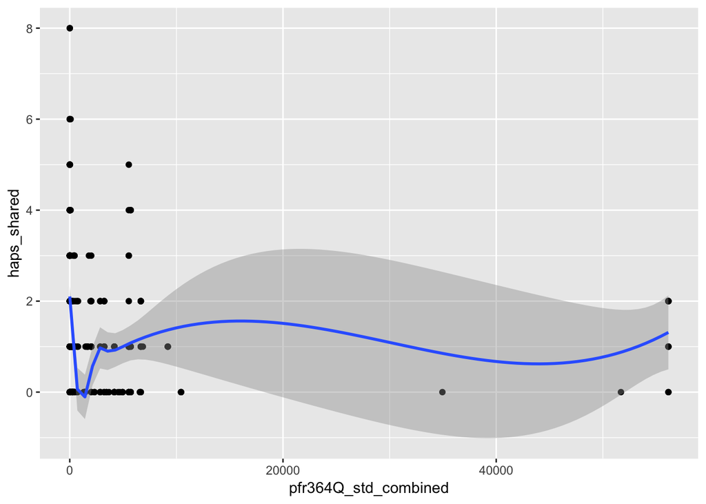

```r
# look at the natural form of pfr364Q_std_combined through the LOWESS curve
# plot the lowess graph
plot_loess = ggplot(data=csp_abdomens) +
  geom_point(aes(x=pfr364Q_std_combined,y=haps_shared)) +
  geom_smooth(aes(x=pfr364Q_std_combined,y=haps_shared),method="loess")
plot_loess
```

Now look at the linear coding of pfr364Q_std_combined.

```r
model1=glm(haps_shared~pfr364Q_std_combined,family=poisson(link = "log"),data=csp_abdomens)
summary(model1)
```

```
##
## Call:
## glm(formula = haps_shared ~ pfr364Q_std_combined, family = poisson(link = "log"),
##     data = csp_abdomens)
##
## Deviance Residuals:
##     Min       1Q   Median       3Q      Max
## -1.7084  -1.6771  -0.3992   0.4587   3.7607
##
## Coefficients:
##                        Estimate Std. Error z value Pr(>|z|)
## (Intercept)           3.780e-01  4.793e-02   7.886 3.12e-15 ***
## pfr364Q_std_combined -8.831e-06  5.385e-06  -1.640    0.101
## ---
## Signif. codes:  0 '***' 0.001 '**' 0.01 '*' 0.05 '.' 0.1 ' ' 1
##
## (Dispersion parameter for poisson family taken to be 1)
##
##     Null deviance: 554.46  on 337  degrees of freedom
## Residual deviance: 551.36  on 336  degrees of freedom
## AIC: 1127.8
##
## Number of Fisher Scoring iterations: 5
```

```r
# exponentiate coefficient
exp(-8.831e-06)
```

```
## [1] 0.9999912
```

```r
# pull out log likelihood test value
logLik(model1)
```

```
## 'log Lik.' -561.9222 (df=2)
```

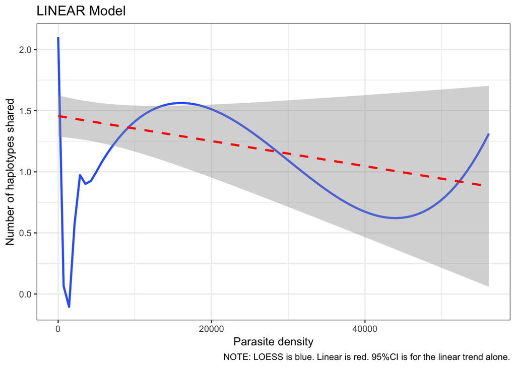

```r
# plot the linear model fit
linear_plot = ggplot(csp_abdomens, aes(x=pfr364Q_std_combined, y=haps_shared)) +
  labs(title="LINEAR Model",
       x="Parasite density",
       y="Number of haplotypes shared",
       caption="NOTE: LOESS is blue. Linear is red. 95%CI is for the linear trend alone.") +
  geom_smooth(method="loess", se = F) +
  geom_smooth(method="glm", formula = y ~x, color="red", linetype="dashed") +
  theme_bw()
linear_plot
```

Now look at the quadratic coding of pfr364Q_std_combined.

```r
# first make the quadratic term
csp_abdomens$pfr364Q_std_combined_quad = csp_abdomens$pfr364Q_std_combined*csp_abdomens$pfr364Q_std_combined
# then run the model
model2=glm(haps_shared~pfr364Q_std_combined+pfr364Q_std_combined_quad,family=poisson(link = "log"),data=csp_abdomens)
summary(model2)
```

```
##
## Call:
## glm(formula = haps_shared ~ pfr364Q_std_combined + pfr364Q_std_combined_quad,
##     family = poisson(link = "log"), data = csp_abdomens)
##
## Deviance Residuals:
##     Min       1Q   Median       3Q      Max
## -1.8184  -1.4078  -0.4853   0.5750   3.5409
##
## Coefficients:
##                             Estimate Std. Error z value Pr(>|z|)
## (Intercept)                5.028e-01  5.253e-02   9.570  < 2e-16 ***
## pfr364Q_std_combined      -1.321e-04  2.763e-05  -4.780 1.75e-06 ***
## pfr364Q_std_combined_quad  2.277e-09  4.954e-10   4.597 4.29e-06 ***
## ---
## Signif. codes:  0 '***' 0.001 '**' 0.01 '*' 0.05 '.' 0.1 ' ' 1
##
## (Dispersion parameter for poisson family taken to be 1)
##
##     Null deviance: 554.46  on 337  degrees of freedom
## Residual deviance: 526.76  on 335  degrees of freedom
## AIC: 1105.2
##
## Number of Fisher Scoring iterations: 5
```

```r
# exponentiate coefficient
exp(-1.321e-04)
```

```
## [1] 0.9998679
```

```r
exp(2.277e-09)
```

```
## [1] 1
```

```r
# pull out log likelihood test value
logLik(model2)
```

```
## 'log Lik.' -549.6248 (df=3)
```

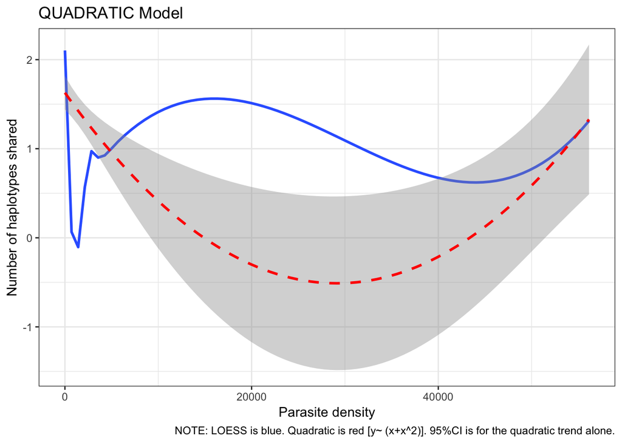

```r
csp_abdomens$pred.quad = model2$fitted.values
# plot the model fit
quadratic_plot = ggplot(csp_abdomens, aes(x=pfr364Q_std_combined, y=haps_shared)) +
  labs(title="QUADRATIC Model",
       x="Parasite density",
       y="Number of haplotypes shared",
       caption="NOTE: LOESS is blue. Quadratic is red [y~ (x+x^2)]. 95%CI is for the quadratic trend alone.") +
  geom_smooth(method="loess", se = F) +
  geom_smooth(method="glm", formula = y ~poly(x,2), color="red", linetype="dashed") +
  theme_bw()
quadratic_plot
```

Now look at the cubic coding of pfr364Q_std_combined.

```r
# first make the cubic term
csp_abdomens$pfr364Q_std_combined_cubed = csp_abdomens$pfr364Q_std_combined*csp_abdomens$pfr364Q_std_combined*csp_abdomens$pfr364Q_std_combined
# then run the model
model3=glm(haps_shared~pfr364Q_std_combined+pfr364Q_std_combined_quad+pfr364Q_std_combined_cubed,family=poisson(link = "log"),data=csp_abdomens)
summary(model3)
```

```
##
## Call:
## glm(formula = haps_shared ~ pfr364Q_std_combined + pfr364Q_std_combined_quad +
##     pfr364Q_std_combined_cubed, family = poisson(link = "log"),
##     data = csp_abdomens)
##
## Deviance Residuals:
##     Min       1Q   Median       3Q      Max
## -1.8183  -1.4082  -0.4853   0.5744   3.5411
##
## Coefficients:
##                              Estimate Std. Error z value Pr(>|z|)
## (Intercept)                 5.026e-01  5.340e-02   9.413  < 2e-16 ***
## pfr364Q_std_combined       -1.317e-04  3.943e-05  -3.340 0.000839 ***
## pfr364Q_std_combined_quad   2.213e-09  4.341e-09   0.510 0.610193
## pfr364Q_std_combined_cubed  1.015e-15  6.816e-14   0.015 0.988124
## ---
## Signif. codes:  0 '***' 0.001 '**' 0.01 '*' 0.05 '.' 0.1 ' ' 1
##
## (Dispersion parameter for poisson family taken to be 1)
##
##     Null deviance: 554.46  on 337  degrees of freedom
## Residual deviance: 526.76  on 334  degrees of freedom
## AIC: 1107.2
##
## Number of Fisher Scoring iterations: 5
```

```r
# exponentiate coefficient
exp(-1.317e-04)
```

```
## [1] 0.9998683
```

```r
exp(2.213e-09)
```

```
## [1] 1
```

```r
exp(1.015e-15)
```

```
## [1] 1
```

```r
# pull out log likelihood test value
logLik(model3)
```

```
## 'log Lik.' -549.6247 (df=4)
```

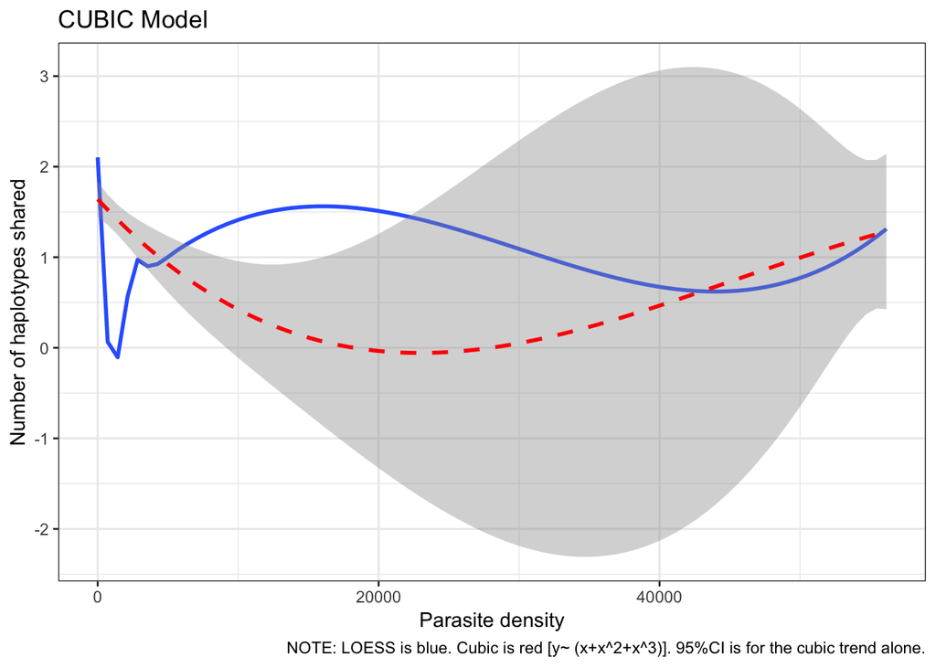

```r
csp_abdomens$pred.quad.cubed = model3$fitted.values
# plot the model fit
cubic_plot = ggplot(csp_abdomens, aes(x=pfr364Q_std_combined, y=haps_shared)) +
  labs(title="CUBIC Model",
       x="Parasite density",
       y="Number of haplotypes shared",
       caption="NOTE: LOESS is blue. Cubic is red [y~ (x+x^2+x^3)]. 95%CI is for the cubic trend alone.") +
  geom_smooth(method="loess", se = F) +
  geom_smooth(method="glm", formula = y ~poly(x,3), color="red", linetype="dashed") +
  theme_bw()
cubic_plot
```

Now look at the categorical coding of pfr364Q_std_combined.

```r
# first make the categorical term
csp_abdomens$pfr364Q_std_combined_cat = ifelse(csp_abdomens$pfr364Q_std_combined<100,"under_rdt_detection",
  "over_rdt_detection")
table(csp_abdomens$pfr364Q_std_combined_cat,csp_abdomens$pfr364Q_std_combined, useNA = "always")
```

[output not shown]

[output cut: 155 more lines]

```
##
##                       6581.06302182585 6662.32678497437 6856.1032698045
##   over_rdt_detection                 2               11               1
##   under_rdt_detection                0                0               0
##   <NA>                               0                0               0
##
##                       9195.38507062935 10437.9872621454 34951.1938952076
##   over_rdt_detection                 3                3                1
##   under_rdt_detection                0                0                0
##   <NA>                               0                0                0
##
##                       51697.8529392425 56148.9883310108 <NA>
##   over_rdt_detection                 1               11    0
##   under_rdt_detection                0                0    0
##   <NA>                               0                0    0
```

```r
csp_abdomens$pfr364Q_std_combined_cat = as.factor(csp_abdomens$pfr364Q_std_combined_cat)
# then run the model
model4=glm(haps_shared~pfr364Q_std_combined_cat,family=poisson(link = "log"),data=csp_abdomens)
summary(model4)
```

```
##
## Call:
## glm(formula = haps_shared ~ pfr364Q_std_combined_cat, family = poisson(link = "log"),
##     data = csp_abdomens)
##
## Deviance Residuals:
##     Min       1Q   Median       3Q      Max
## -2.0750  -1.3238  -0.1054   0.5447   3.0510
##
## Coefficients:
##                                             Estimate Std. Error z value
## (Intercept)                                 -0.13206    0.07670  -1.722
## pfr364Q_std_combined_catunder_rdt_detection  0.89882    0.09544   9.418
##                                             Pr(>|z|)
## (Intercept)                                   0.0851 .
## pfr364Q_std_combined_catunder_rdt_detection   <2e-16 ***
## ---
## Signif. codes:  0 '***' 0.001 '**' 0.01 '*' 0.05 '.' 0.1 ' ' 1
##
## (Dispersion parameter for poisson family taken to be 1)
##
##     Null deviance: 554.46  on 337  degrees of freedom
## Residual deviance: 460.68  on 336  degrees of freedom
## AIC: 1037.2
##
## Number of Fisher Scoring iterations: 5
```

```r
# exponentiate coefficient
exp(0.89882)
```

```
## [1] 2.456702
```

```r
# pull out log likelihood test value
logLik(model4)
```

```
## 'log Lik.' -516.5862 (df=2)
```

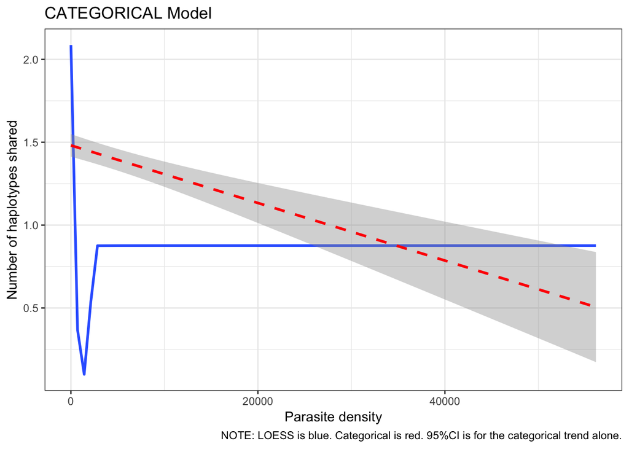

```r
csp_abdomens$pred.cat = model4$fitted.values
# plot the model fit
categorical_plot = ggplot(csp_abdomens, aes(x=pfr364Q_std_combined, y=pred.cat)) +
  labs(title="CATEGORICAL Model",
       x="Parasite density",
       y="Number of haplotypes shared",
       caption="NOTE: LOESS is blue. Categorical is red. 95%CI is for the categorical trend alone.") +
  geom_smooth(method="loess", se = F) +
  geom_smooth(method="glm", formula = y ~x, color="red", linetype="dashed") +
  theme_bw()
categorical_plot
```

Now look at the natural log (ln) coding of pfr364Q_std_combined.

```r
# first make the categorical term
csp_abdomens$pfr364Q_std_combined_ln = log(csp_abdomens$pfr364Q_std_combined)
# then run the model
model5=glm(haps_shared~pfr364Q_std_combined_ln,family=poisson(link = "log"),data=csp_abdomens)
summary(model5)
```

```
##
## Call:
## glm(formula = haps_shared ~ pfr364Q_std_combined_ln, family = poisson(link = "log"),
##     data = csp_abdomens)
##
## Deviance Residuals:
##     Min       1Q   Median       3Q      Max
## -2.3993  -1.3057  -0.2030   0.6002   3.1117
##
## Coefficients:
##                         Estimate Std. Error z value Pr(>|z|)
## (Intercept)              0.86509    0.06587  13.133   <2e-16 ***
## pfr364Q_std_combined_ln -0.12288    0.01363  -9.016   <2e-16 ***
## ---
## Signif. codes:  0 '***' 0.001 '**' 0.01 '*' 0.05 '.' 0.1 ' ' 1
##
## (Dispersion parameter for poisson family taken to be 1)
##
##     Null deviance: 554.46  on 337  degrees of freedom
## Residual deviance: 471.77  on 336  degrees of freedom
## AIC: 1048.3
##
## Number of Fisher Scoring iterations: 5
```

```r
# exponentiate coefficient
exp(-0.12288)
```

```
## [1] 0.8843698
```

```r
# pull out log likelihood test value
logLik(model5)
```

```
## 'log Lik.' -522.1273 (df=2)
```

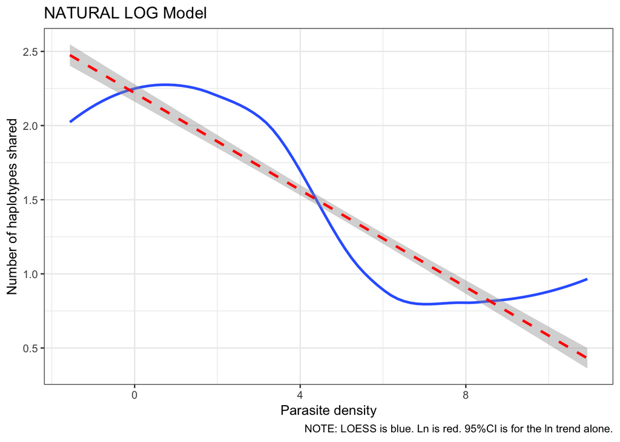

```r
# plot the model fit
ln_plot = ggplot(csp_abdomens, aes(x=pfr364Q_std_combined_ln, y=pred.cat)) +
  labs(title="NATURAL LOG Model",
       x="Parasite density",
       y="Number of haplotypes shared",
       caption="NOTE: LOESS is blue. Ln is red. 95%CI is for the ln trend alone.") +
  geom_smooth(method="loess", se = F) +
  geom_smooth(method="glm", formula = y ~x, color="red", linetype="dashed") +
  theme_bw()
ln_plot
```

```r
# compare quadratic and linear models
lrtest(model1,model2) # quadratic is better than linear
```

```
## Likelihood ratio test for MLE method
## Chi-squared 1 d.f. =  24.59477 , P value =  7.074333e-07
```

```r
# compare cubic and linear models
lrtest(model1,model3) # cubic is better than linear
```

```
## Likelihood ratio test for MLE method
## Chi-squared 2 d.f. =  24.595 , P value =  4.563146e-06
```

```r
# compare the quadratic and cubic
lrtest(model2,model3) # quadratic is better than cubic
```

```
## Likelihood ratio test for MLE method
## Chi-squared 1 d.f. =  0.0002225145 , P value =  0.9880985
```

## Assess functional form coding for age

Assessed functional form coding for the age of the participants at baseline.

First plot the natural form using a LOWESS curve.

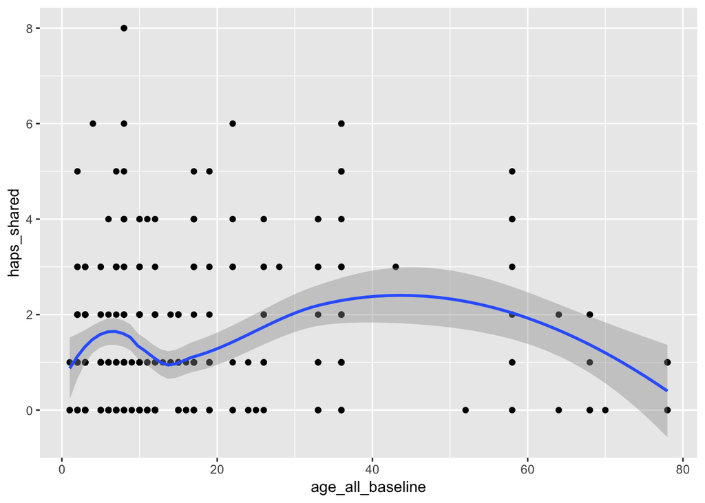

```r
# look at the natural form of age through the LOWESS curve
# plot the lowess graph
plot_loess = ggplot(data=csp_abdomens) +
  geom_point(aes(x=age_all_baseline,y=haps_shared)) +
  geom_smooth(aes(x=age_all_baseline,y=haps_shared),method="loess")
plot_loess
```

Now look at the linear coding of age_all_baseline.

```r
model1=glm(haps_shared~age_all_baseline,family=poisson(link = "log"),data=csp_abdomens)
summary(model1)
```

```
##
## Call:
## glm(formula = haps_shared ~ age_all_baseline, family = poisson(link = "log"),
##     data = csp_abdomens)
##
## Deviance Residuals:
##     Min       1Q   Median       3Q      Max
## -1.8835  -1.6547  -0.3437   0.4997   3.8646
##
## Coefficients:
##                  Estimate Std. Error z value Pr(>|z|)
## (Intercept)      0.288568   0.065103   4.432 9.32e-06 ***
## age_all_baseline 0.003648   0.002643   1.380    0.167
## ---
## Signif. codes:  0 '***' 0.001 '**' 0.01 '*' 0.05 '.' 0.1 ' ' 1
##
## (Dispersion parameter for poisson family taken to be 1)
##
##     Null deviance: 554.46  on 337  degrees of freedom
## Residual deviance: 552.64  on 336  degrees of freedom
## AIC: 1129.1
##
## Number of Fisher Scoring iterations: 5
```

```r
# exponentiate coefficient
exp(0.003648)
```

```
## [1] 1.003655
```

```r
# pull out log likelihood test value
logLik(model1)
```

```
## 'log Lik.' -562.5616 (df=2)
```

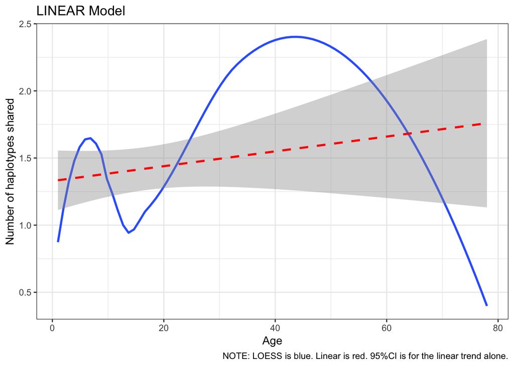

```r
# plot the linear model fit
linear_plot = ggplot(csp_abdomens, aes(x=age_all_baseline, y=haps_shared)) +
  labs(title="LINEAR Model",
       x="Age",
       y="Number of haplotypes shared",
       caption="NOTE: LOESS is blue. Linear is red. 95%CI is for the linear trend alone.") +
  geom_smooth(method="loess", se = F) +
  geom_smooth(method="glm", formula = y ~x, color="red", linetype="dashed") +
  theme_bw()
linear_plot
```

Now look at the quadratic coding of age_all_baseline.

```r
# first make the quadratic term
csp_abdomens$age_all_baseline_quad = csp_abdomens$age_all_baseline*csp_abdomens$age_all_baseline
# then run the model
model2=glm(haps_shared~age_all_baseline+age_all_baseline_quad,family=poisson(link = "log"),data=csp_abdomens)
summary(model2)
```

```
##
## Call:
## glm(formula = haps_shared ~ age_all_baseline + age_all_baseline_quad,
##     family = poisson(link = "log"), data = csp_abdomens)
##
## Deviance Residuals:
##     Min       1Q   Median       3Q      Max
## -1.9256  -1.5934  -0.3064   0.5580   3.9446
##
## Coefficients:
##                         Estimate Std. Error z value Pr(>|z|)
## (Intercept)            0.0632835  0.1031148   0.614  0.53940
## age_all_baseline       0.0289608  0.0090580   3.197  0.00139 **
## age_all_baseline_quad -0.0003769  0.0001317  -2.862  0.00421 **
## ---
## Signif. codes:  0 '***' 0.001 '**' 0.01 '*' 0.05 '.' 0.1 ' ' 1
##
## (Dispersion parameter for poisson family taken to be 1)
##
##     Null deviance: 554.46  on 337  degrees of freedom
## Residual deviance: 544.02  on 335  degrees of freedom
## AIC: 1122.5
##
## Number of Fisher Scoring iterations: 5
```

```r
# exponentiate coefficient
exp(0.0289608)
```

```
## [1] 1.029384
```

```r
exp(-0.0003769)
```

```
## [1] 0.9996232
```

```r
# pull out log likelihood test value
logLik(model2)
```

```
## 'log Lik.' -558.2537 (df=3)
```

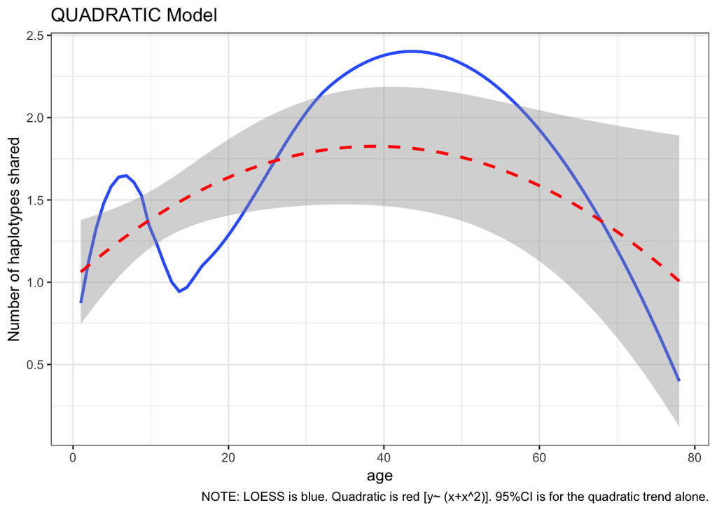

```r
csp_abdomens$pred.quad = model2$fitted.values
# plot the model fit
quadratic_plot = ggplot(csp_abdomens, aes(x=age_all_baseline, y=haps_shared)) +
  labs(title="QUADRATIC Model",
       x="age",
       y="Number of haplotypes shared",
       caption="NOTE: LOESS is blue. Quadratic is red [y~ (x+x^2)]. 95%CI is for the quadratic trend alone.") +
  geom_smooth(method="loess", se = F) +
  geom_smooth(method="glm", formula = y ~poly(x,2), color="red", linetype="dashed") +
  theme_bw()
quadratic_plot
```

Now look at the cubic coding of age_all_baseline.

```r
# first make the cubic term
csp_abdomens$age_all_baseline_cubed = csp_abdomens$age_all_baseline*csp_abdomens$age_all_baseline*csp_abdomens$age_all_baseline
# then run the model
model3=glm(haps_shared~age_all_baseline+age_all_baseline_quad+age_all_baseline_cubed,family=poisson(link = "log"),data=csp_abdomens)
summary(model3)
```

```
##
## Call:
## glm(formula = haps_shared ~ age_all_baseline + age_all_baseline_quad +
##     age_all_baseline_cubed, family = poisson(link = "log"), data = csp_abdomens)
##
## Deviance Residuals:
##     Min       1Q   Median       3Q      Max
## -2.2712  -1.5980  -0.2880   0.5918   3.9791
##
## Coefficients:
##                          Estimate Std. Error z value Pr(>|z|)
## (Intercept)             4.221e-01  1.389e-01   3.039  0.00238 **
## age_all_baseline       -3.783e-02  2.075e-02  -1.823  0.06826 .
## age_all_baseline_quad   2.251e-03  7.610e-04   2.957  0.00310 **
## age_all_baseline_cubed -2.555e-05  7.466e-06  -3.423  0.00062 ***
## ---
## Signif. codes:  0 '***' 0.001 '**' 0.01 '*' 0.05 '.' 0.1 ' ' 1
##
## (Dispersion parameter for poisson family taken to be 1)
##
##     Null deviance: 554.46  on 337  degrees of freedom
## Residual deviance: 531.31  on 334  degrees of freedom
## AIC: 1111.8
##
## Number of Fisher Scoring iterations: 5
```

```r
# exponentiate coefficient
exp(-3.783e-02)
```

```
## [1] 0.9628766
```

```r
exp(2.251e-03)
```

```
## [1] 1.002254
```

```r
exp(-2.555e-05)
```

```
## [1] 0.9999745
```

```r
# pull out log likelihood test value
logLik(model3)
```

```
## 'log Lik.' -551.8983 (df=4)
```

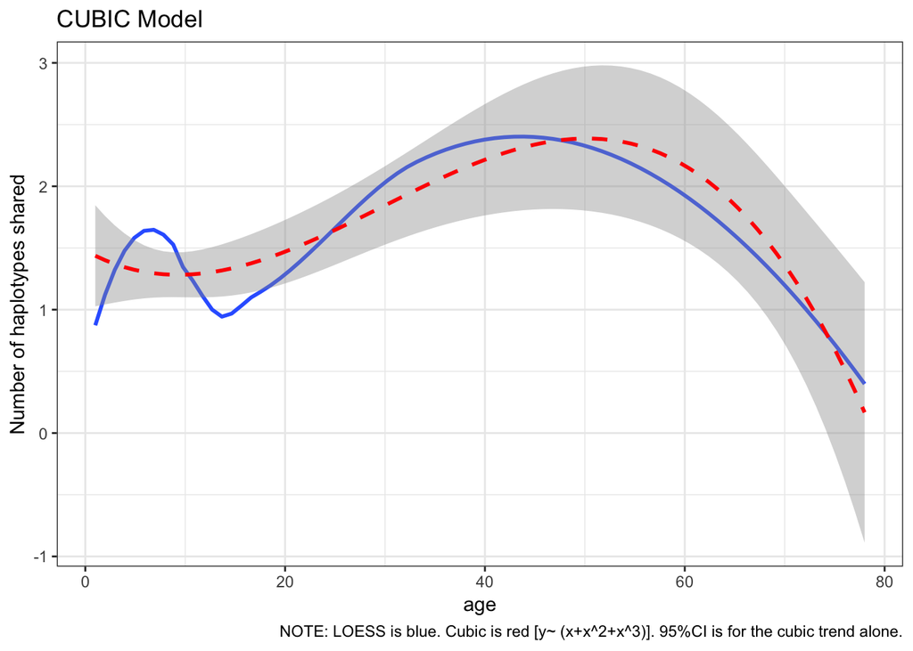

```r
csp_abdomens$pred.cubed = model3$fitted.values
# plot the model fit
cubic_plot = ggplot(csp_abdomens, aes(x=age_all_baseline, y=haps_shared)) +
  labs(title="CUBIC Model",
       x="age",
       y="Number of haplotypes shared",
       caption="NOTE: LOESS is blue. Cubic is red [y~ (x+x^2+x^3)]. 95%CI is for the cubic trend alone.") +
  geom_smooth(method="loess", se = F) +
  geom_smooth(method="glm", formula = y ~poly(x,3), color="red", linetype="dashed") +
  theme_bw()
cubic_plot
```

```r
# first make the categorical term
csp_abdomens$age_cat_baseline = factor(csp_abdomens$age_cat_baseline)
csp_abdomens$age_cat_baseline = relevel(csp_abdomens$age_cat_baseline,ref = ">15 years")
# then run the model
model4=glm(haps_shared~age_cat_baseline,family=poisson(link = "log"),data=csp_abdomens)
summary(model4)
```

```
##
## Call:
## glm(formula = haps_shared ~ age_cat_baseline, family = poisson(link = "log"),
##     data = csp_abdomens)
##
## Deviance Residuals:
##     Min       1Q   Median       3Q      Max
## -1.8573  -1.5855  -0.2376   0.6098   4.0159
##
## Coefficients:
##                            Estimate Std. Error z value Pr(>|z|)
## (Intercept)                 0.54509    0.07293   7.474 7.78e-14 ***
## age_cat_baseline<5 years   -0.24660    0.14645  -1.684  0.09221 .
## age_cat_baseline5-15 years -0.31650    0.09832  -3.219  0.00129 **
## ---
## Signif. codes:  0 '***' 0.001 '**' 0.01 '*' 0.05 '.' 0.1 ' ' 1
##
## (Dispersion parameter for poisson family taken to be 1)
##
##     Null deviance: 554.46  on 337  degrees of freedom
## Residual deviance: 544.05  on 335  degrees of freedom
## AIC: 1122.5
##
## Number of Fisher Scoring iterations: 5
```

```r
# exponentiate coefficient
exp(-0.24660)
```

```
## [1] 0.7814532
```

```r
exp(-0.31650)
```

```
## [1] 0.728695
```

```r
# pull out log likelihood test value
logLik(model4)
```

```
## 'log Lik.' -558.2707 (df=3)
```

[figure not shown]

```r
csp_abdomens$pred.cat = model4$fitted.values
# plot the model fit
categorical_plot = ggplot(csp_abdomens, aes(x=age_cat_baseline, y=pred.cat)) +
  labs(title="CATEGORICAL Model",
       x="age",
       y="Number of haplotypes shared",
       caption="NOTE: LOESS is blue. Categorical is red. 95%CI is for the categorical trend alone.") +
  geom_smooth(method="loess", se = F) +
  geom_smooth(method="glm", formula = y ~x, color="red", linetype="dashed") +
  theme_bw()
categorical_plot
```

Now look at the natural log (ln) coding of age_all_baseline.

```r
# first make the categorical term
csp_abdomens$age_all_baseline_ln = log(csp_abdomens$age_all_baseline)
# then run the model
model5=glm(haps_shared~age_all_baseline_ln,family=poisson(link = "log"),data=csp_abdomens)
summary(model5)
```

```
##
## Call:
## glm(formula = haps_shared ~ age_all_baseline_ln, family = poisson(link = "log"),
##     data = csp_abdomens)
##
## Deviance Residuals:
##     Min       1Q   Median       3Q      Max
## -1.8337  -1.6475  -0.3571   0.5003   3.8655
##
## Coefficients:
##                     Estimate Std. Error z value Pr(>|z|)
## (Intercept)          0.13257    0.13617   0.974   0.3303
## age_all_baseline_ln  0.08881    0.05149   1.725   0.0846 .
## ---
## Signif. codes:  0 '***' 0.001 '**' 0.01 '*' 0.05 '.' 0.1 ' ' 1
##
## (Dispersion parameter for poisson family taken to be 1)
##
##     Null deviance: 554.46  on 337  degrees of freedom
## Residual deviance: 551.48  on 336  degrees of freedom
## AIC: 1128
##
## Number of Fisher Scoring iterations: 5
```

```r
# exponentiate coefficient
exp(0.08881)
```

```
## [1] 1.092873
```

```r
# pull out log likelihood test value
logLik(model5)
```

```
## 'log Lik.' -561.9855 (df=2)
```

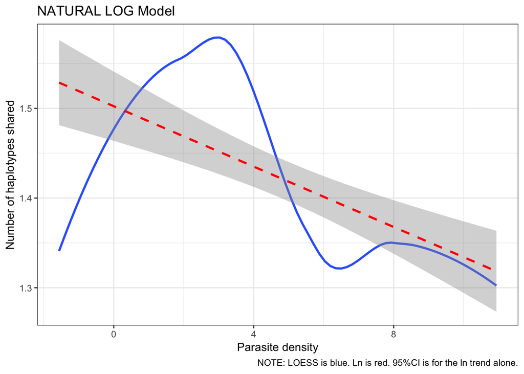

```r
# plot the model fit
ln_plot = ggplot(csp_abdomens, aes(x=pfr364Q_std_combined_ln, y=pred.cat)) +
  labs(title="NATURAL LOG Model",
       x="Parasite density",
       y="Number of haplotypes shared",
       caption="NOTE: LOESS is blue. Ln is red. 95%CI is for the ln trend alone.") +
  geom_smooth(method="loess", se = F) +
  geom_smooth(method="glm", formula = y ~x, color="red", linetype="dashed") +
  theme_bw()
ln_plot
```

```r
# compare quadratic and linear models
lrtest(model1,model2) # quadratic is better than linear
```

```
## Likelihood ratio test for MLE method
## Chi-squared 1 d.f. =  8.615968 , P value =  0.003332286
```

```r
# compare cubic and linear models
lrtest(model1,model3) # cubic is better than linear
```

```
## Likelihood ratio test for MLE method
## Chi-squared 2 d.f. =  21.32669 , P value =  2.338663e-05
```

```r
# compare the quadratic and cubic
lrtest(model2,model3) # cubic is better than quadratic
```

```
## Likelihood ratio test for MLE method
## Chi-squared 1 d.f. =  12.71072 , P value =  0.0003635647
```

## Clean up the variables in the data set

```r
colnames(csp_abdomens)
```

```
##  [1] "sample_id_human"            "sample_id_abdomen"
##  [3] "haps_shared"                "human_date"
##  [5] "sample_name_final"          "age_cat_baseline"
##  [7] "unq_memID"                  "village_name"
##  [9] "HH_ID"                      "pfr364Q_std_combined"
## [11] "age_all_baseline"           "aim2_exposure"
## [13] "mosquito_date"              "total_num_mosq_in_hh"
## [15] "pfr364Q_std_combined_quad"  "pred.quad"
## [17] "pfr364Q_std_combined_cubed" "pred.quad.cubed"
## [19] "pfr364Q_std_combined_cat"   "pred.cat"
## [21] "pfr364Q_std_combined_ln"    "age_all_baseline_quad"
## [23] "age_all_baseline_cubed"     "pred.cubed"
## [25] "age_all_baseline_ln"
```

```r
csp_abdomens = csp_abdomens %>%
  dplyr::select(-c(pfr364Q_std_combined_quad,pfr364Q_std_combined_cubed,pfr364Q_std_combined_cubed,pfr364Q_std_combined_ln,pred.quad,pred.quad.cubed,pred.cat,pred.cubed,age_all_baseline_ln))
colnames(csp_abdomens)
```

```
##  [1] "sample_id_human"          "sample_id_abdomen"
##  [3] "haps_shared"              "human_date"
##  [5] "sample_name_final"        "age_cat_baseline"
##  [7] "unq_memID"                "village_name"
##  [9] "HH_ID"                    "pfr364Q_std_combined"
## [11] "age_all_baseline"         "aim2_exposure"
## [13] "mosquito_date"            "total_num_mosq_in_hh"
## [15] "pfr364Q_std_combined_cat" "age_all_baseline_quad"
## [17] "age_all_baseline_cubed"
```

## Relevel the village_name variables

```r
table(csp_abdomens$village_name, useNA = "always")
```

```
##
##  Kinesamo    Maruti Sitabicha      <NA>
##       163       175         0         0
```

```r
csp_abdomens$village_name = as.factor(ifelse(csp_abdomens$village_name=="Kinesamo","Kinesamo","Maruti"))
table(csp_abdomens$village_name, useNA = "always")
```

```
##
## Kinesamo   Maruti     <NA>
##      163      175        0
```

## Check for muticollinearity

```r
# comparing aim2_exposure vs. haps_shared
asymptomatic = csp_abdomens[which(csp_abdomens$aim2_exposure=="asymptomatic infection"),]
symptomatic = csp_abdomens[which(csp_abdomens$aim2_exposure=="symptomatic infection"),]
asymptomatic_mean = mean(asymptomatic$haps_shared, na.rm = TRUE)
symptomatic_mean = mean(symptomatic$haps_shared, na.rm = TRUE)
pooled_sd = sd(append(asymptomatic$haps_shared, symptomatic$haps_shared), na.rm = TRUE)
(symptomatic_mean - asymptomatic_mean)/pooled_sd
```

```
## [1] -0.2910055
```

```r
# comparing aim2_exposure vs. age_cat_baseline
table(csp_abdomens$aim2_exposure,csp_abdomens$age_cat_baseline, useNA = "always")
```

```
##
##                          >15 years <5 years 5-15 years <NA>
##   asymptomatic infection        92       42        129    0
##   symptomatic infection         17        4         54    0
##   <NA>                           0        0          0    0
```

```r
firstmodel = glm(aim2_exposure ~ age_cat_baseline, data=csp_abdomens, family=binomial(link="logit"))
summary(firstmodel)
```

```
##
## Call:
## glm(formula = aim2_exposure ~ age_cat_baseline, family = binomial(link = "logit"),
##     data = csp_abdomens)
##
## Deviance Residuals:
##     Min       1Q   Median       3Q      Max
## -0.8363  -0.8363  -0.5823  -0.4265   2.2101
##
## Coefficients:
##                            Estimate Std. Error z value Pr(>|z|)
## (Intercept)                 -1.6886     0.2640  -6.396 1.59e-10 ***
## age_cat_baseline<5 years    -0.6628     0.5860  -1.131   0.2580
## age_cat_baseline5-15 years   0.8177     0.3098   2.640   0.0083 **
## ---
## Signif. codes:  0 '***' 0.001 '**' 0.01 '*' 0.05 '.' 0.1 ' ' 1
##
## (Dispersion parameter for binomial family taken to be 1)
##
##     Null deviance: 357.80  on 337  degrees of freedom
## Residual deviance: 343.59  on 335  degrees of freedom
## AIC: 349.59
##
## Number of Fisher Scoring iterations: 4
```

```r
exp(-0.6628)
```

```
## [1] 0.5154062
```

```r
exp(0.8177)
```

```
## [1] 2.265284
```

```r
# comparing aim2_exposure vs. village_name
table(csp_abdomens$aim2_exposure,csp_abdomens$village_name, useNA = "always")
```

```
##
##                          Kinesamo Maruti <NA>
##   asymptomatic infection      112    151    0
##   symptomatic infection        51     24    0
##   <NA>                          0      0    0
```

```r
firstmodel = glm(village_name ~ aim2_exposure, data=csp_abdomens, family=binomial(link="logit"))
summary(firstmodel)
```

```
##
## Call:
## glm(formula = village_name ~ aim2_exposure, family = binomial(link = "logit"),
##     data = csp_abdomens)
##
## Deviance Residuals:
##    Min      1Q  Median      3Q     Max
## -1.307  -1.307   1.053   1.053   1.510
##
## Coefficients:
##                                    Estimate Std. Error z value Pr(>|z|)
## (Intercept)                          0.2988     0.1247   2.396 0.016579
## aim2_exposuresymptomatic infection  -1.0526     0.2772  -3.797 0.000146
##
## (Intercept)                        *
## aim2_exposuresymptomatic infection ***
## ---
## Signif. codes:  0 '***' 0.001 '**' 0.01 '*' 0.05 '.' 0.1 ' ' 1
##
## (Dispersion parameter for binomial family taken to be 1)
##
##     Null deviance: 468.14  on 337  degrees of freedom
## Residual deviance: 452.82  on 336  degrees of freedom
## AIC: 456.82
##
## Number of Fisher Scoring iterations: 4
```

```r
exp(-1.0526)
```

```
## [1] 0.3490291
```

```r
# comparing aim2_exposure vs. pfr364Q_std_combined_cat
table(csp_abdomens$aim2_exposure,csp_abdomens$pfr364Q_std_combined_cat, useNA = "always")
```

```
##
##                          over_rdt_detection under_rdt_detection <NA>
##   asymptomatic infection                139                 124    0
##   symptomatic infection                  55                  20    0
##   <NA>                                    0                   0    0
```

```r
firstmodel = glm(pfr364Q_std_combined_cat ~ aim2_exposure, data=csp_abdomens, family=binomial(link="logit"))
summary(firstmodel)
```

```
##
## Call:
## glm(formula = pfr364Q_std_combined_cat ~ aim2_exposure, family = binomial(link = "logit"),
##     data = csp_abdomens)
##
## Deviance Residuals:
##     Min       1Q   Median       3Q      Max
## -1.1293  -1.1293  -0.7876   1.2263   1.6259
##
## Coefficients:
##                                    Estimate Std. Error z value Pr(>|z|)
## (Intercept)                         -0.1142     0.1235  -0.924  0.35526
## aim2_exposuresymptomatic infection  -0.8974     0.2889  -3.107  0.00189 **
## ---
## Signif. codes:  0 '***' 0.001 '**' 0.01 '*' 0.05 '.' 0.1 ' ' 1
##
## (Dispersion parameter for binomial family taken to be 1)
##
##     Null deviance: 461.14  on 337  degrees of freedom
## Residual deviance: 450.73  on 336  degrees of freedom
## AIC: 454.73
##
## Number of Fisher Scoring iterations: 4
```

```r
exp(-0.8974)
```

```
## [1] 0.4076281
```

```r
# comparing haps_shared vs. age_cat_baseline
cat1 = csp_abdomens[which(csp_abdomens$age_cat_baseline=="<5 years"),]
cat2 = csp_abdomens[which(csp_abdomens$age_cat_baseline=="5-15 years"),]
cat3 = csp_abdomens[which(csp_abdomens$age_cat_baseline==">15 years"),]
cat1_mean = mean(cat1$haps_shared, na.rm = TRUE)
cat2_mean = mean(cat2$haps_shared, na.rm = TRUE)
cat3_mean = mean(cat3$haps_shared, na.rm = TRUE)
pooled_sd = sd(append(cat2$haps_shared, cat3$haps_shared), na.rm = TRUE)
(cat2_mean - cat3_mean)/pooled_sd
```

```
## [1] -0.3061966
```

```r
# comparing haps_shared vs. village_name
kinesamo = csp_abdomens[which(csp_abdomens$village_name=="Kinesamo"),]
maruti = csp_abdomens[which(csp_abdomens$village_name=="Maruti"),]
kinesamo_mean = mean(kinesamo$haps_shared, na.rm = TRUE)
maruti_mean = mean(maruti$haps_shared, na.rm = TRUE)
pooled_sd = sd(append(kinesamo$haps_shared, maruti$haps_shared), na.rm = TRUE)
(kinesamo_mean - maruti_mean)/pooled_sd
```

```
## [1] 0.05143942
```

```r
# comparing haps_shared vs. pfr364Q_std_combined_cat
cat1 = csp_abdomens[which(csp_abdomens$pfr364Q_std_combined_cat=="over_rdt_detection"),]
cat2 = csp_abdomens[which(csp_abdomens$pfr364Q_std_combined_cat=="under_rdt_detection"),]
cat1_mean = mean(cat1$haps_shared, na.rm = TRUE)
cat2_mean = mean(cat2$haps_shared, na.rm = TRUE)
pooled_sd = sd(append(cat2$haps_shared, cat1$haps_shared), na.rm = TRUE)
(cat2_mean - cat1_mean)/pooled_sd
```

```
## [1] 0.8498206
```

```r
# comparing age_cat_baseline vs. village_name
table(csp_abdomens$village_name,csp_abdomens$age_cat_baseline, useNA = "always")
```

```
##
##            >15 years <5 years 5-15 years <NA>
##   Kinesamo        41       18        104    0
##   Maruti          68       28         79    0
##   <NA>             0        0          0    0
```

```r
firstmodel = glm(village_name ~ age_cat_baseline, data=csp_abdomens, family=binomial(link="logit"))
summary(firstmodel)
```

```
##
## Call:
## glm(formula = village_name ~ age_cat_baseline, family = binomial(link = "logit"),
##     data = csp_abdomens)
##
## Deviance Residuals:
##     Min       1Q   Median       3Q      Max
## -1.3984  -1.0631   0.9714   0.9964   1.2962
##
## Coefficients:
##                            Estimate Std. Error z value Pr(>|z|)
## (Intercept)                  0.5059     0.1977   2.559  0.01050 *
## age_cat_baseline<5 years    -0.0641     0.3611  -0.178  0.85908
## age_cat_baseline5-15 years  -0.7809     0.2477  -3.152  0.00162 **
## ---
## Signif. codes:  0 '***' 0.001 '**' 0.01 '*' 0.05 '.' 0.1 ' ' 1
##
## (Dispersion parameter for binomial family taken to be 1)
##
##     Null deviance: 468.14  on 337  degrees of freedom
## Residual deviance: 456.19  on 335  degrees of freedom
## AIC: 462.19
##
## Number of Fisher Scoring iterations: 4
```

```r
exp(-0.0641)
```

```
## [1] 0.9379112
```

```r
exp(-0.7809)
```

```
## [1] 0.4579936
```

```r
# comparing age_cat_baseline vs. pfr364Q_std_combined_cat
table(csp_abdomens$pfr364Q_std_combined_cat,csp_abdomens$age_cat_baseline, useNA = "always")
```

```
##
##                       >15 years <5 years 5-15 years <NA>
##   over_rdt_detection         34       29        131    0
##   under_rdt_detection        75       17         52    0
##   <NA>                        0        0          0    0
```

```r
firstmodel = glm(pfr364Q_std_combined_cat ~ age_cat_baseline, data=csp_abdomens, family=binomial(link="logit"))
summary(firstmodel)
```

```
##
## Call:
## glm(formula = pfr364Q_std_combined_cat ~ age_cat_baseline, family = binomial(link = "logit"),
##     data = csp_abdomens)
##
## Deviance Residuals:
##     Min       1Q   Median       3Q      Max
## -1.5264  -0.8177  -0.8177   0.8647   1.5863
##
## Coefficients:
##                            Estimate Std. Error z value Pr(>|z|)
## (Intercept)                  0.7911     0.2067   3.827 0.000130 ***
## age_cat_baseline<5 years    -1.3252     0.3689  -3.593 0.000327 ***
## age_cat_baseline5-15 years  -1.7151     0.2638  -6.501    8e-11 ***
## ---
## Signif. codes:  0 '***' 0.001 '**' 0.01 '*' 0.05 '.' 0.1 ' ' 1
##
## (Dispersion parameter for binomial family taken to be 1)
##
##     Null deviance: 461.14  on 337  degrees of freedom
## Residual deviance: 414.34  on 335  degrees of freedom
## AIC: 420.34
##
## Number of Fisher Scoring iterations: 4
```

```r
exp(-1.3252)
```

```
## [1] 0.2657498
```

```r
exp(-1.7151)
```

```
## [1] 0.1799457
```

```r
# comparing village_name vs. pfr364Q_std_combined
table(csp_abdomens$village_name,csp_abdomens$pfr364Q_std_combined_cat, useNA = "always")
```

```
##
##            over_rdt_detection under_rdt_detection <NA>
##   Kinesamo                119                  44    0
##   Maruti                   75                 100    0
##   <NA>                      0                   0    0
```

```r
firstmodel = glm(pfr364Q_std_combined_cat ~ village_name, data=csp_abdomens, family=binomial(link="logit"))
summary(firstmodel)
```

```
##
## Call:
## glm(formula = pfr364Q_std_combined_cat ~ village_name, family = binomial(link = "logit"),
##     data = csp_abdomens)
##
## Deviance Residuals:
##     Min       1Q   Median       3Q      Max
## -1.3018  -0.7933  -0.7933   1.0579   1.6184
##
## Coefficients:
##                    Estimate Std. Error z value Pr(>|z|)
## (Intercept)         -0.9949     0.1764  -5.639 1.71e-08 ***
## village_nameMaruti   1.2826     0.2334   5.496 3.89e-08 ***
## ---
## Signif. codes:  0 '***' 0.001 '**' 0.01 '*' 0.05 '.' 0.1 ' ' 1
##
## (Dispersion parameter for binomial family taken to be 1)
##
##     Null deviance: 461.14  on 337  degrees of freedom
## Residual deviance: 429.14  on 336  degrees of freedom
## AIC: 433.14
##
## Number of Fisher Scoring iterations: 4
```

```r
exp(1.2826)
```

```
## [1] 3.606003
```

## write out the final model data set for csp abdomen sharing

```r
# write_csv(csp_abdomens,"Desktop/spat21_csp_abdomen_sharing_final_model_data_31OCT2019.csv")
# write_rds(csp_abdomens,"Desktop/spat21_csp_abdomen_sharing_final_model_data_31OCT2019.rds")
```